# EasyVisa-Adv-ML-Project

[figure not shown]

Artificial Intelligence and Machine Learning

Advance Machine Learning - Project

[figure not shown]

EasyVisa : visa application processing

# **Problem Statement**

## Business Context

Business communities in the United States are facing high demand for human resources, but one of the constant challenges is identifying and attracting the right talent, which is perhaps the most important element in remaining competitive. Companies in the United States look for hard-working, talented, and qualified individuals both locally as well as abroad.

The **Immigration and Nationality Act (INA)** of the US permits foreign workers to come to the United States to work on either a temporary or permanent basis. The act also protects US workers against adverse impacts on their wages or working conditions by ensuring US employers' compliance with statutory requirements when they hire foreign workers to fill workforce shortages. The immigration programs are administered by the **Office of Foreign Labor Certification (OFLC)**.

OFLC processes job certification applications for employers seeking to bring foreign workers into the United States and grants certifications in those cases where employers can demonstrate that there are not sufficient US workers available to perform the work at wages that meet or exceed the wage paid for the occupation in the area of intended employment.

### Challenge

In FY 2016, the OFLC processed 775,979 employer applications for 1,699,957 positions for temporary and permanent labor certifications. This was a nine percent increase in the overall number of processed applications from the previous year. The process of reviewing every case is becoming a tedious task as the number of applicants is increasing every year.

## Objective

OFLC has hired the firm **EasyVisa** for data-driven solutions to handle the challenge of shortlisting candidates having higher chances of VISA approval.

- Build a classification model to predict the likelihood of VISA approval for each applicant.
- Identify key factors (drivers) influencing VISA certification outcomes.
- Provide recommendations on whether a candidate’s VISA should be certified or denied based on data-driven insights.

## Dataset

The data contains the following attributes of the applicants (employees) and their employers. The detailed data dictionary is given below.

1. **case_id**: ID of each visa application
2. **continent**: Information of continent the employee
3. **education_of_employee**: Information of education of the employee
4. **has_job_experience**: Does the employee has any job experience? Y= Yes; N = No
5. **requires_job_training**: Does the employee require any job training? Y = Yes; N = No
6. **no_of_employees**: Number of employees in the employer's company
7. **yr_of_estab**: Year in which the employer's company was established
8. **region_of_employment**: Information of foreign worker's intended region of employment in the US.
9. **prevailing_wage**: Average wage paid to similarly employed workers in a specific occupation in the area of intended employment. The purpose of the prevailing wage is to ensure that the foreign worker is not underpaid compared to other workers offering the same or similar service in the same area of employment.
10. **unit_of_wage**: Unit of prevailing wage. Values include Hourly, Weekly, Monthly, and Yearly.
11. **full_time_position**: Is the position of work full-time? Y = Full-Time Position; N = Part-Time Position
12. **case_status**: Flag indicating if the Visa was certified or not

# **Importing the necessary libraries**

```python
# Libraries to help with reading and manipulating data
import pandas as pd
import numpy as np

# Libaries to help with data visualization
import matplotlib.pyplot as plt
import seaborn as sns
%matplotlib inline

# Library to preprocess for label encoding
from sklearn.preprocessing import LabelEncoder

# To impute missing values
from sklearn.impute import SimpleImputer

# Library to split data
from sklearn.model_selection import train_test_split

# To tune different models
from sklearn.model_selection import GridSearchCV

# Libraries to build logistic regression model
from sklearn.linear_model import LogisticRegression

# Libraries to build decision tree classifier
from sklearn.tree import DecisionTreeClassifier
from sklearn import tree

# Libraries for ensemble technique : bagging
from sklearn.ensemble import BaggingClassifier, RandomForestClassifier

# Libraries for ensemble technique : boosting
from sklearn.ensemble import AdaBoostClassifier, GradientBoostingClassifier
from xgboost import XGBClassifier

# Libraries for under and oversampling
from imblearn.over_sampling import SMOTE
from imblearn.under_sampling import RandomUnderSampler

# To perform statistical analysis
import scipy.stats as stats

# To get diferent metric scores
from sklearn import metrics
from sklearn.metrics import (
    f1_score,
    accuracy_score,
    recall_score,
    precision_score,
    confusion_matrix,
    ConfusionMatrixDisplay,
    make_scorer,
)

# Library to suppress warnings or deprecation notes
import warnings
warnings.filterwarnings("ignore")
```

# **Loading the dataset**

```python
# load the CSV file containing data from local storage of colab notebook
application_data = pd.read_csv("EasyVisa.csv")

# copying data to another variable as backup to avoid any changes to original data
data = application_data.copy()
```

# **1. Exploratory Data Analysis**

## View the first and last 10 rows of the dataset.

```python
#get the first 10 records
data.head(10)
```

|  | case_id | continent | education_of_employee | has_job_experience | requires_job_training | no_of_employees | yr_of_estab | region_of_employment | prevailing_wage | unit_of_wage | full_time_position | case_status |
| --- | --- | --- | --- | --- | --- | --- | --- | --- | --- | --- | --- | --- |
| 0 | EZYV01 | Asia | High School | N | N | 14513 | 2007 | West | 592.2029 | Hour | Y | Denied |
| 1 | EZYV02 | Asia | Master's | Y | N | 2412 | 2002 | Northeast | 83425.6500 | Year | Y | Certified |
| 2 | EZYV03 | Asia | Bachelor's | N | Y | 44444 | 2008 | West | 122996.8600 | Year | Y | Denied |
| 3 | EZYV04 | Asia | Bachelor's | N | N | 98 | 1897 | West | 83434.0300 | Year | Y | Denied |
| 4 | EZYV05 | Africa | Master's | Y | N | 1082 | 2005 | South | 149907.3900 | Year | Y | Certified |
| 5 | EZYV06 | Asia | Master's | Y | N | 2339 | 2012 | South | 78252.1400 | Year | Y | Certified |
| 6 | EZYV07 | Asia | Bachelor's | N | N | 4985 | 1994 | South | 53635.3900 | Year | Y | Certified |
| 7 | EZYV08 | North America | Bachelor's | Y | N | 3035 | 1924 | West | 418.2298 | Hour | Y | Denied |
| 8 | EZYV09 | Asia | Bachelor's | N | N | 4810 | 2012 | Midwest | 74362.1900 | Year | Y | Certified |
| 9 | EZYV10 | Europe | Doctorate | Y | N | 2251 | 1995 | South | 67514.7600 | Year | Y | Certified |

```python
# get the last 10 records
data.tail(10)
```

|  | case_id | continent | education_of_employee | has_job_experience | requires_job_training | no_of_employees | yr_of_estab | region_of_employment | prevailing_wage | unit_of_wage | full_time_position | case_status |
| --- | --- | --- | --- | --- | --- | --- | --- | --- | --- | --- | --- | --- |
| 25470 | EZYV25471 | North America | Master's | Y | N | 2272 | 1970 | Northeast | 516.4101 | Hour | Y | Certified |
| 25471 | EZYV25472 | Asia | High School | N | N | 40224 | 1962 | Island | 75587.4200 | Year | Y | Certified |
| 25472 | EZYV25473 | Asia | High School | N | N | 1346 | 2003 | Midwest | 76155.6000 | Year | N | Certified |
| 25473 | EZYV25474 | Asia | Bachelor's | Y | N | 2421 | 2007 | Northeast | 22845.5600 | Year | Y | Certified |
| 25474 | EZYV25475 | Africa | Doctorate | N | N | 2594 | 1979 | Northeast | 51104.7800 | Year | Y | Certified |
| 25475 | EZYV25476 | Asia | Bachelor's | Y | Y | 2601 | 2008 | South | 77092.5700 | Year | Y | Certified |
| 25476 | EZYV25477 | Asia | High School | Y | N | 3274 | 2006 | Northeast | 279174.7900 | Year | Y | Certified |
| 25477 | EZYV25478 | Asia | Master's | Y | N | 1121 | 1910 | South | 146298.8500 | Year | N | Certified |
| 25478 | EZYV25479 | Asia | Master's | Y | Y | 1918 | 1887 | West | 86154.7700 | Year | Y | Certified |
| 25479 | EZYV25480 | Asia | Bachelor's | Y | N | 3195 | 1960 | Midwest | 70876.9100 | Year | Y | Certified |

**Observations :**

- Multiple categorical fields can be observed. They offer strong potential for segmentation and group-wise analysis, especially against the dependent variable `case_status`
  - `continent`
  - `education_of_employee`
  - `has_job_experience`
  - `requires_job_training`
  - `region_of_employment`,
  - `unit_of_wage`,
  - `full_time_position`
- `prevailing_wage` (numerical) varies significantly and is tied to `unit_of_wage` (Hour vs. Year). This needs to be normalized for meaningful comparisons. (there is also Weekly and Monthly)
- `yr_of_estab` and `no_of_employees` provide context on the employer and can help in correlating outcomes against the dependent variable `case_status`

## Understand the shape of the dataset.

```python
# get the shape of data
data.shape
```

```
(25480, 12)
```

- The application dataset has 25480 rows and 12 columns

## Check the data types of the columns for the dataset.

```python
# get data info
data.info()
```

```
<class 'pandas.core.frame.DataFrame'>
RangeIndex: 25480 entries, 0 to 25479
Data columns (total 12 columns):
 #   Column                 Non-Null Count  Dtype
---  ------                 --------------  -----
 0   case_id                25480 non-null  object
 1   continent              25480 non-null  object
 2   education_of_employee  25480 non-null  object
 3   has_job_experience     25480 non-null  object
 4   requires_job_training  25480 non-null  object
 5   no_of_employees        25480 non-null  int64
 6   yr_of_estab            25480 non-null  int64
 7   region_of_employment   25480 non-null  object
 8   prevailing_wage        25480 non-null  float64
 9   unit_of_wage           25480 non-null  object
 10  full_time_position     25480 non-null  object
 11  case_status            25480 non-null  object
dtypes: float64(1), int64(2), object(9)
memory usage: 2.3+ MB
```

**Observations :**

## Fixing the data types

```python
# get the object type columns
object_columns = data.select_dtypes(['object'])
object_columns.columns
```

```
Index(['case_id', 'continent', 'education_of_employee', 'has_job_experience',
       'requires_job_training', 'region_of_employment', 'unit_of_wage',
       'full_time_position', 'case_status'],
      dtype='object')
```

```python
# change the column type to category for object type columns
for i in object_columns.columns:
    data[i] = data[i].astype('category')
```

```python
# get data info
data.info()
```

```
<class 'pandas.core.frame.DataFrame'>
RangeIndex: 25480 entries, 0 to 25479
Data columns (total 12 columns):
 #   Column                 Non-Null Count  Dtype
---  ------                 --------------  -----
 0   case_id                25480 non-null  category
 1   continent              25480 non-null  category
 2   education_of_employee  25480 non-null  category
 3   has_job_experience     25480 non-null  category
 4   requires_job_training  25480 non-null  category
 5   no_of_employees        25480 non-null  int64
 6   yr_of_estab            25480 non-null  int64
 7   region_of_employment   25480 non-null  category
 8   prevailing_wage        25480 non-null  float64
 9   unit_of_wage           25480 non-null  category
 10  full_time_position     25480 non-null  category
 11  case_status            25480 non-null  category
dtypes: category(9), float64(1), int64(2)
memory usage: 2.0 MB
```

- We can see that the memory usage has decreased from 2.3+ MB to 2.0 MB
- The memory reduction is more visible in larger datasets

## Statistical summary of the dataset.

```python
# display the statistical summary of all columns
data.describe(include='all').T
```

|  | count | unique | top | freq | mean | std | min | 25% | 50% | 75% | max |
| --- | --- | --- | --- | --- | --- | --- | --- | --- | --- | --- | --- |
| case_id | 25480 | 25480 | EZYV01 | 1 | NaN | NaN | NaN | NaN | NaN | NaN | NaN |
| continent | 25480 | 6 | Asia | 16861 | NaN | NaN | NaN | NaN | NaN | NaN | NaN |
| education_of_employee | 25480 | 4 | Bachelor's | 10234 | NaN | NaN | NaN | NaN | NaN | NaN | NaN |
| has_job_experience | 25480 | 2 | Y | 14802 | NaN | NaN | NaN | NaN | NaN | NaN | NaN |
| requires_job_training | 25480 | 2 | N | 22525 | NaN | NaN | NaN | NaN | NaN | NaN | NaN |
| no_of_employees | 25480.0 | NaN | NaN | NaN | 5667.04321 | 22877.928848 | -26.0 | 1022.0 | 2109.0 | 3504.0 | 602069.0 |
| yr_of_estab | 25480.0 | NaN | NaN | NaN | 1979.409929 | 42.366929 | 1800.0 | 1976.0 | 1997.0 | 2005.0 | 2016.0 |
| region_of_employment | 25480 | 5 | Northeast | 7195 | NaN | NaN | NaN | NaN | NaN | NaN | NaN |
| prevailing_wage | 25480.0 | NaN | NaN | NaN | 74455.814592 | 52815.942327 | 2.1367 | 34015.48 | 70308.21 | 107735.5125 | 319210.27 |
| unit_of_wage | 25480 | 4 | Year | 22962 | NaN | NaN | NaN | NaN | NaN | NaN | NaN |
| full_time_position | 25480 | 2 | Y | 22773 | NaN | NaN | NaN | NaN | NaN | NaN | NaN |
| case_status | 25480 | 2 | Certified | 17018 | NaN | NaN | NaN | NaN | NaN | NaN | NaN |

**Observations :**

- Top applicants who get visa certified are from Asia, with Bachelor's degree, having work experience and without the requirement for job related training
- Maximum data appears to be available for 'year' as the Unit of wage
- Visa applications have been for jobs that are full time and based in NorthEast of US
- `prevailing_wage` has high dispersion (mean ≈ 74k, std ≈ 52k) and ranges from \$2.13 to \$319210, showing significant pay variability across roles. This is also due to the wage being provided for different `unit_of_wage` as in day, week, month, year
- `no_of_employees` ranges from **-26 (invalid)** to 602,069, indicating potential data quality issues and extreme outliers.
- `has_job_experience`, `requires_job_training`, `full_time_position` are booleans
- Companies span from 1800 to 2016, with a median year of 1997, suggesting a wide mix of company ages.
- Applicants are from 6 different continents
- Applications are made to 5 unique regions across US
- Education of applicants is in 4 unique categories

**Note**

- As observed earlier `case_id` is unique and can be dropped
- Data cleaning and careful handling of categorical and wage related variables are to be done before creating models.

## Unique values of categorical columns

```python
# Print the unique values i.e. ,category for continent, education_of_employee, region_of_employment columns
for category in ['continent', 'education_of_employee', 'region_of_employment', 'unit_of_wage']:
    print(f"Unique values in `{category}` are ")
    print(categorical_columns[category].value_counts())
    print('-'*50)
```

```
Unique values in `continent` are
continent
Asia             16861
Europe            3732
North America     3292
South America      852
Africa             551
Oceania            192
Name: count, dtype: int64
--------------------------------------------------
Unique values in `education_of_employee` are
education_of_employee
Bachelor's     10234
Master's        9634
High School     3420
Doctorate       2192
Name: count, dtype: int64
--------------------------------------------------
Unique values in `region_of_employment` are
region_of_employment
Northeast    7195
South        7017
West         6586
Midwest      4307
Island        375
Name: count, dtype: int64
--------------------------------------------------
Unique values in `unit_of_wage` are
unit_of_wage
Year     22962
Hour      2157
Week       272
Month       89
Name: count, dtype: int64
--------------------------------------------------
```

- Above confirms the 4 different Units of wages, 6 continents, 5 regions applications made for and 4 different education qualification

## Drop columns with all unique values

```python
# checking for unique values in case_id column
data["case_id"].nunique()
```

```
25480
```

- Since all the values in ID column are unique we can drop it

```python
# drop the ID column and do it inplace
data.drop(["case_id"], axis=1, inplace=True)
```

## Univariate Analysis

### Numerical (continuous) variables and histogram

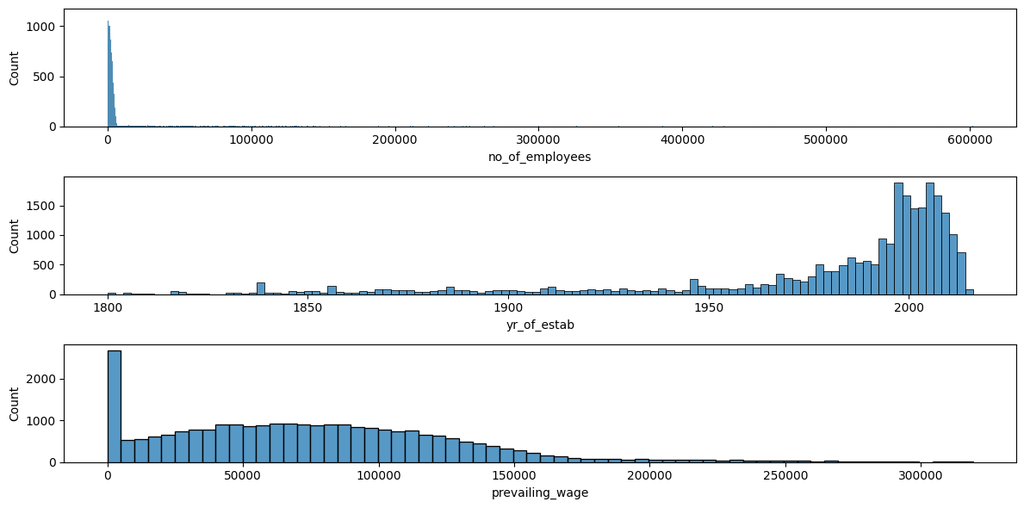

```python
# define the plot figure size
plt.figure(figsize=(12, 6))

# define list of continuous numerical features to plot histogram to analyse the distribution and skewness
num_features = ['no_of_employees', 'yr_of_estab', 'prevailing_wage']

# plotting the histogram for each numerical feature
for i, feature in enumerate(num_features):
    plt.subplot(3, 1, i+1)    # assign a subplot in the main plot
    sns.histplot(data=data, x=feature)    # plot the histogram on log scale

plt.tight_layout();   # to add spacing between plots
plt.show()
```

**Observations :**

- `no_of_employees` is heavily right skewed indicating most companies have a relatively small number of employees, while a few outliers have very large employee counts.
- `yr_of_estab` is left skewed indicating many companies being established in recent years and a few companies are old (before 1950) and some very old (before 1850)
- `prevailing_wage` is right skewed indicating most wages cluster toward the lower end, with a few employees earning significantly higher wages (in the \$150k - \$300k range)

### Numerical (continuous) variables and Box plots

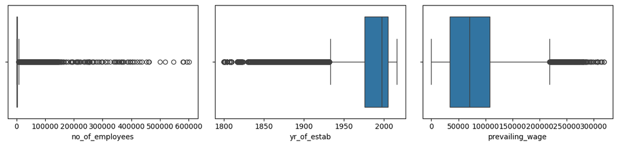

```python
# define the plot figure size
plt.figure(figsize=(12, 8))

# plotting the boxplots for each numerical feature
for i, feature in enumerate(num_features):
    plt.subplot(3, 3, i+1)    # assign a subplot in the main plot
    sns.boxplot(data=data, x=feature)    # plot the boxplot

plt.tight_layout();   # to add spacing between plots
plt.show()
```

**Observations:**

- `no_of_employees` : Right-skewed distribution.
  - box is very narrow and close to the lower end, while there are many extreme outliers extending far to the right.
  - This indicates, majority of companies have a small number of employees
  - Few very large companies have extremely high employee counts
- `yr_of_estab` : Left-skewed distribution.
  - box is skewed to the right, with many outliers on the left (older years).
  - Most companies were established after 1950, with a heavy concentration in recent decades
  - number of older establishments exist (pre-1900) but are outliers.
- `prevailing_wage` : Right-skewed distribution.
  - box is positioned toward the lower end of the range, with many outliers on the higher end.
  - Most employees receive wages in the lower-to-mid range.
  - There are numerous high-wage outliers, indicating a few high-paid roles

Overall the observations from histplot and boxplot are compimenting each other.

### Category variables and Count plots

```
continent: Asia: 66.2% | Europe: 14.6% | North America: 12.9% | South America: 3.3% | Africa: 2.2% | Oceania: 0.8%
education_of_employee: Bachelor's: 40.2% | Master's: 37.8% | High School: 13.4% | Doctorate: 8.6%
has_job_experience: Y: 58.1% | N: 41.9%
requires_job_training: N: 88.4% | Y: 11.6%
region_of_employment: Northeast: 28.2% | South: 27.5% | West: 25.8% | Midwest: 16.9% | Island: 1.5%
unit_of_wage: Year: 90.1% | Hour: 8.5% | Week: 1.1% | Month: 0.3%
full_time_position: Y: 89.4% | N: 10.6%
case_status: Certified: 66.8% | Denied: 33.2%
```

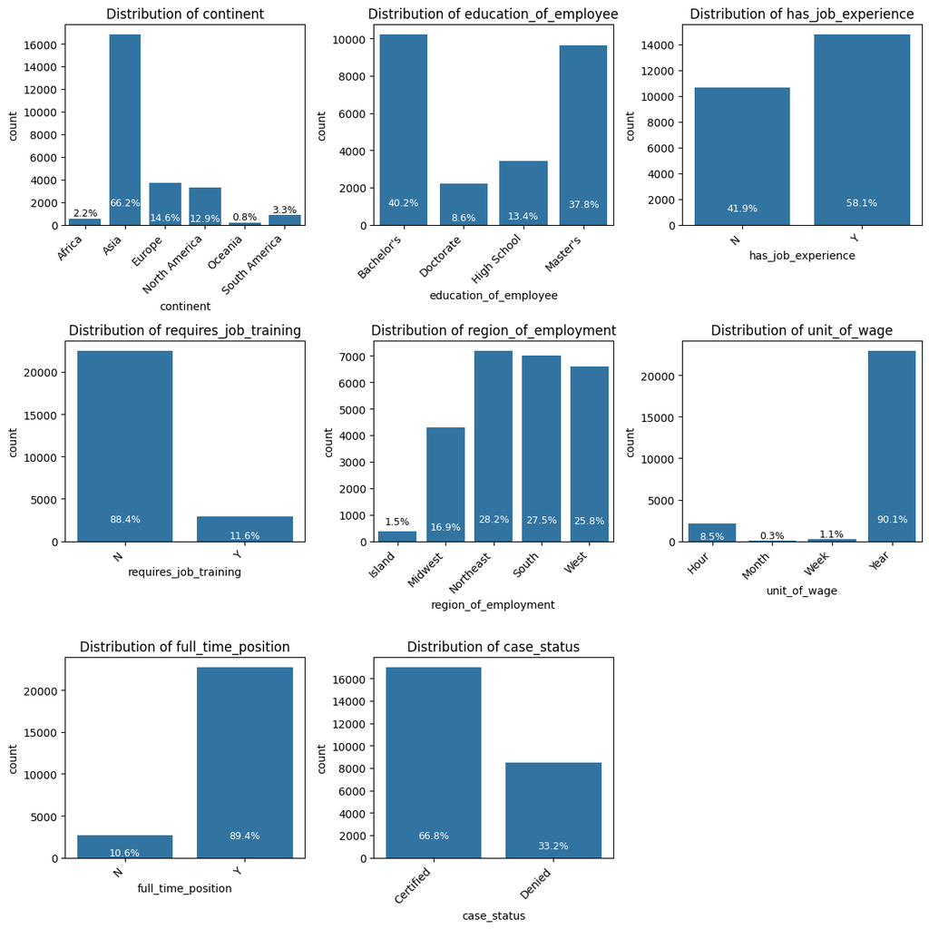

```python
# define list of categorical features to plot countplot for analysis
# List of categorical features
cat_features = [
    'continent', 'education_of_employee', 'has_job_experience',
    'requires_job_training', 'region_of_employment', 'unit_of_wage',
    'full_time_position', 'case_status'
]

# Print feature values in percentage
for feature in cat_features:
    percentages = 100 * data[feature].value_counts(normalize=True)
    print(f"{feature}: ", end='')
    print(' | '.join([f"{idx}: {val:.1f}%" for idx, val in percentages.items()]))
print('\n')

# Plot setup: 4 rows × 2 columns = 8 subplots
plt.figure(figsize=(12, 12))
total = len(data)

for i, feature in enumerate(cat_features):
    ax = plt.subplot(3,3, i + 1)
    sns.countplot(data=data, x=feature, ax=ax)

    # Add percentage labels to each bar
    for p in ax.patches:
        height = p.get_height()
        if height == 0:
            continue
        percentage = f'{100 * height / total:.1f}%'
        label_x = p.get_x() + p.get_width() / 2.

        if height < 0.05 * total:  # Short bars = show label above the bar
            ax.text(
                label_x,
                height + (0.01 * total),
                percentage,
                color='black',
                fontsize=9,
                ha='center'
            )
        else:  # Tall bars = show label inside with white text
            ax.text(
                label_x,
                height * 0.1,
                percentage,
                color='white',
                fontsize=9,
                ha='center'
            )

    ax.set_title(f'Distribution of {feature}')
    ax.set_xticklabels(ax.get_xticklabels(), rotation=45, ha='right')

plt.tight_layout()
plt.show()
```

**Observations :**

- Most visa applicants are from Asia (66.2%), followed by Europe (14.6%) and North America (12.9%), indicating a strong representation from Asia in U.S. visa applications
- A large proportion of employees have either a Bachelor’s (40.2%) or Master’s degree (37.8%), suggesting that most applicants possess higher education levels (while Doctorate (8.6%) and High School (13.4%) are less common)
- A large proportion of applicants have job experience (58.1%), though a significant portion (41.9%) still do not.
- 88.4% of applicants do not require job training, indicating that most candidates are considered job-ready
- The majority of employment is intended in the Northeast (28.2%), South (27.5%), and West (25.8%) regions of the U.S., implying concentrated regional demand for foreign workers.
- The most common unit of wage is Year (90.1%), followed by Hour (8.5%), with Month and Week being rare. 90.1% of prevailing wages reported on a yearly basis suggests that most job offers are long-term roles rather than short contracts.
- 89.4% of positions are full-time, reinforcing the idea that employers are sponsoring foreign workers primarily for full-time roles.
- Case approval rate is 66.8% (Certified), while 33.2% are Denied, indicating that about two-thirds of the visa applications in this dataset are successful

## Bivariate Analysis

### Numerical variables correlation using Heatmap

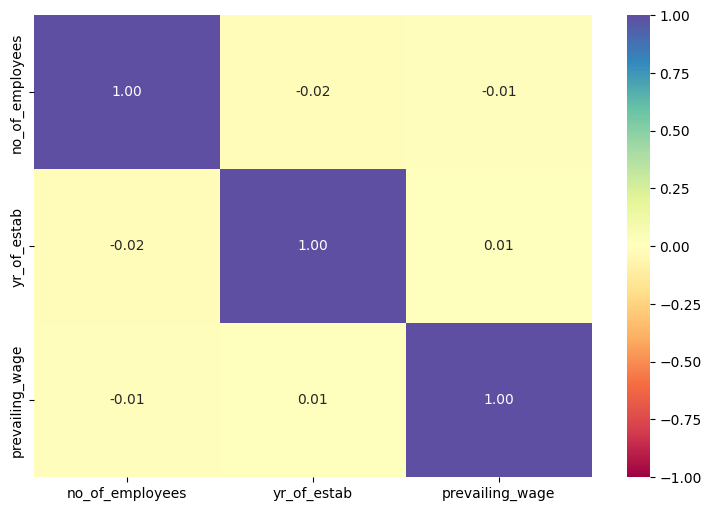

```python
num_features = ['no_of_employees', 'yr_of_estab', 'prevailing_wage']

# defining the size of the plot
plt.figure(figsize=(9, 6))

# plotting the heatmap for correlation
sns.heatmap(
    data[num_features].corr(),annot=True, vmin=-1, vmax=1, fmt=".2f", cmap="Spectral"
);
plt.show()
```

**Observations:**

- linear correlations within numerical features (`no_of_employees`, `yr_of_estab`, `prevailing_wage`) is checked
- The heatmap shows very weak correlations (all near 0), meaning
  - These features are largely independent of one another.
  - There's no multicollinearity concern among them.
- This doesn’t help much with bivariate analysis with respect to the target `case_status`

### Numerical variables correlation with case status using Boxplot

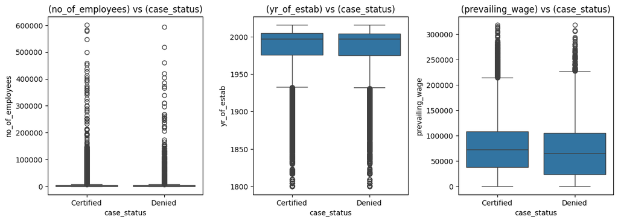

```python
# define the plot figure size
plt.figure(figsize=(12, 12))

# plotting the boxplots for each numerical feature
for i, feature in enumerate(num_features):
    plt.subplot(3, 3, i+1)    # assign a subplot in the main plot
    plt.title(f"({feature}) vs (case_status)")
    sns.boxplot(data=data, x='case_status', y=feature)    # plot the boxplot

plt.tight_layout();   # to add spacing between plots
plt.show()
```

**Observations:**

1. Number of Employees vs Case Status
   - Distribution is very similar across both outcomes with a large number of outliers.
   - Number of employees doesn't show strong discriminatory power visually.
2. Year of Establishment vs Case Status
   - Slight trend that more recently established companies get slightly more approvals. But this difference is minimal.
3. Prevailing Wage vs Case Status
   - Distributions of prevailing_wage for both Certified and Denied cases have marginal difference in the median
   - Both classes have:
     - Comparable medians.
     - Large overlaps in IQR (interquartile range).
     - Similar spread of outliers.

### Categorical features and target variables using Crosstab

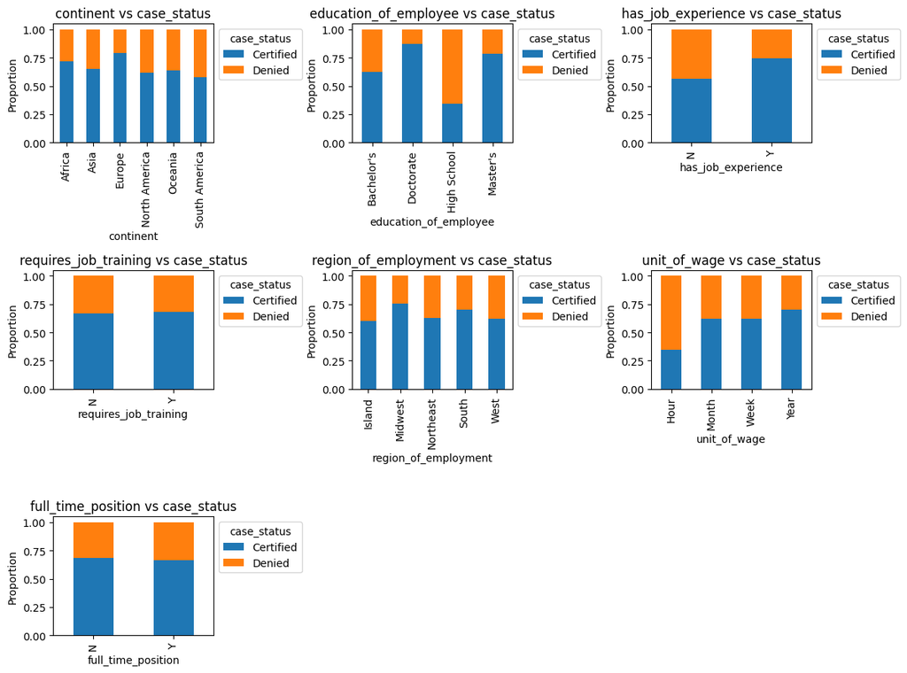

```python
# define list of categorical features to plot countplot for analysis
cat_features = [
    'continent', 'education_of_employee', 'has_job_experience',
    'requires_job_training', 'region_of_employment', 'unit_of_wage',
    'full_time_position']

plt.figure(figsize=(12,9))

# plotting the boxplots for each numerical feature with the percentage in the bars
for i, feature in enumerate(cat_features):
    plt.subplot(3, 3, i+1)    # assign a subplot in the main plot

    # creating a crosstab for case_status vs Category Feature
    tab = pd.crosstab(
        data[feature],
        data['case_status'],
        normalize='index'    # normalizing by dividing each row by its row total
    )

    # Plot within current subplot (ax passed explicitly),
    # creating a stacked bar chart from the normalized crosstab
    tab.plot(kind='bar', stacked=True, ax=plt.gca())

    #chart title
    plt.title(f'{feature} vs case_status')

    # x label
    plt.xlabel(feature)

    # y label
    plt.ylabel('Proportion')

    # adding a legend for the 'case_status' column
    plt.legend(title='case_status', loc='upper left', bbox_to_anchor=(1, 1));

plt.tight_layout()
plt.show()
```

**Observations**

**Summary**

- Education level and wage unit structure emerge as the most discriminating factors, while job training requirements and full-time status appear to have no practical impact on visa certification outcomes.

### Categorical features and target variables using Heatmap

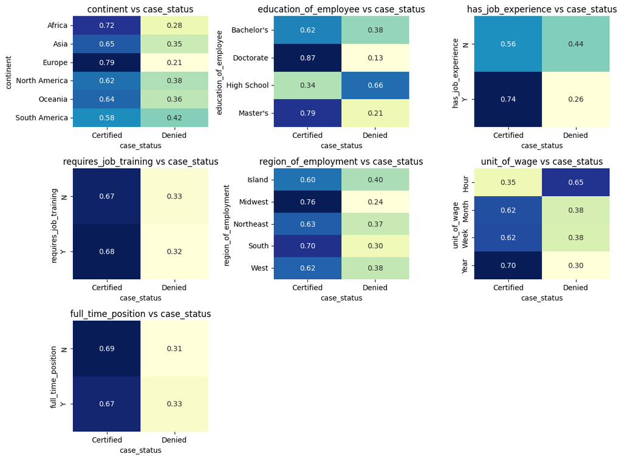

```python
# define categorical features
cat_features = [
    'continent', 'education_of_employee', 'has_job_experience',
    'requires_job_training', 'region_of_employment', 'unit_of_wage',
    'full_time_position'
]

plt.figure(figsize=(12, 9))

#iterate through each categorical feature and compare with outcome param case_status
for i, feature in enumerate(cat_features):
    plt.subplot(3, 3, i + 1)

    # Crosstab of feature vs. case_status normalized by index (rows)
    tab = pd.crosstab(
        data[feature],
        data['case_status'],
        normalize='index'
    )

    # Heatmap of proportions
    sns.heatmap(
        tab,
        annot=True,
        fmt=".2f",
        cmap="YlGnBu",
        cbar=False
    )

    plt.title(f'{feature} vs case_status')
    plt.xlabel('case_status')
    plt.ylabel(feature)

plt.tight_layout()
plt.show()
```

**Observations**

- Heatmap confirms the bivariate analysis observations made on categorical variables with outcome variable (case_status) from crosstab charts

# **2. Data Pre-processing**

## Missing value detection and treatment

```python
# check for missing values
data.isnull().sum()
```

```
continent                0
education_of_employee    0
has_job_experience       0
requires_job_training    0
no_of_employees          0
yr_of_estab              0
region_of_employment     0
prevailing_wage          0
unit_of_wage             0
full_time_position       0
case_status              0
dtype: int64
```

- There are no missing values in the data

## Duplicate value detection and treatment

```python
# checking for duplicate values
data.duplicated().sum()
```

```
np.int64(0)
```

- There are no duplicate values in the data

## Outlier Detection and treatment

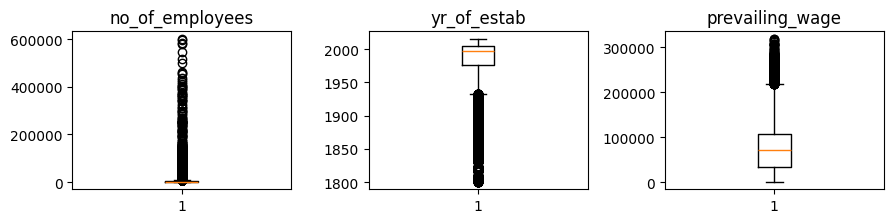

```python
# outlier detection using boxplot
plt.figure(figsize=(12, 8))

for i, variable in enumerate(num_features):
    plt.subplot(4, 4, i + 1)
    plt.boxplot(data[variable], whis=1.5)
    plt.tight_layout()
    plt.title(variable)

plt.show()
```

**Observations**:

### Treat no_of_employees outliers (negative values)

```python
# get the count of no_of_employees less than zero
data[data['no_of_employees'] < 0].shape[0]
```

```
33
```

- There are 33 records with negative value. Given the small set of data, analysing them to check if they should be dropped or imputed can be done

```python
data[data['no_of_employees'] < 0]
```

|  | continent | education_of_employee | has_job_experience | requires_job_training | no_of_employees | yr_of_estab | region_of_employment | prevailing_wage | unit_of_wage | full_time_position | case_status |
| --- | --- | --- | --- | --- | --- | --- | --- | --- | --- | --- | --- |
| 245 | Europe | Master's | N | N | -25 | 1980 | Northeast | 39452.9900 | Year | Y | Certified |
| 378 | Asia | Bachelor's | N | Y | -11 | 2011 | Northeast | 32506.1400 | Year | Y | Denied |
| 832 | South America | Master's | Y | N | -17 | 2002 | South | 129701.9400 | Year | Y | Certified |
| 2918 | Asia | Master's | Y | N | -26 | 2005 | Midwest | 112799.4600 | Year | Y | Certified |
| 6439 | Asia | Bachelor's | N | N | -14 | 2013 | South | 103.9700 | Hour | Y | Denied |
| 6634 | Asia | Bachelor's | Y | N | -26 | 1923 | West | 5247.3200 | Year | Y | Denied |
| 7224 | Europe | Doctorate | N | N | -25 | 1998 | Midwest | 141435.9500 | Year | Y | Certified |
| 7281 | Asia | High School | N | N | -14 | 2000 | Midwest | 58488.5000 | Year | Y | Denied |
| 7318 | Asia | Bachelor's | Y | Y | -26 | 2006 | South | 115005.6100 | Year | Y | Certified |
| 7761 | Asia | Master's | N | N | -11 | 2009 | Midwest | 38457.5100 | Year | Y | Certified |
| 9872 | Europe | Master's | Y | N | -26 | 1996 | South | 37397.0500 | Year | Y | Certified |
| 11493 | Asia | High School | Y | N | -14 | 1999 | South | 27599.3500 | Year | Y | Denied |
| 13471 | North America | Master's | N | N | -17 | 2003 | Northeast | 257.2413 | Hour | Y | Denied |
| 14022 | Asia | Bachelor's | N | Y | -11 | 1946 | Northeast | 108403.5600 | Year | Y | Certified |
| 14146 | Asia | Bachelor's | N | Y | -26 | 1954 | West | 81982.2700 | Year | Y | Certified |
| 14726 | Asia | Master's | N | N | -11 | 2000 | Midwest | 167851.8000 | Year | Y | Certified |
| 15600 | Asia | Bachelor's | N | N | -14 | 2014 | South | 24641.6100 | Year | Y | Denied |
| 15859 | Asia | High School | N | N | -11 | 1969 | South | 44640.6000 | Year | Y | Denied |
| 16157 | Asia | Master's | Y | N | -11 | 1994 | South | 62681.2500 | Year | Y | Certified |
| 16883 | North America | Bachelor's | Y | N | -26 | 1968 | Northeast | 168.1558 | Hour | Y | Denied |
| 17006 | Asia | Doctorate | Y | N | -11 | 1984 | West | 25753.5100 | Year | Y | Denied |
| 17655 | North America | Bachelor's | Y | N | -17 | 2007 | Northeast | 129753.1800 | Year | Y | Denied |
| 17844 | Asia | Bachelor's | N | N | -14 | 2012 | West | 29325.8500 | Year | Y | Denied |
| 17983 | Asia | Bachelor's | N | N | -26 | 2004 | South | 84359.9800 | Year | Y | Denied |
| 20815 | Asia | Bachelor's | N | Y | -17 | 1990 | West | 91897.5700 | Year | Y | Certified |
| 20984 | Europe | Doctorate | Y | N | -14 | 1989 | Midwest | 37012.8000 | Year | Y | Certified |
| 21255 | North America | High School | N | N | -25 | 1987 | South | 99405.4700 | Year | N | Denied |
| 21760 | Asia | Bachelor's | Y | N | -25 | 2000 | West | 100463.5800 | Year | Y | Certified |
| 21944 | Africa | Master's | Y | N | -25 | 1977 | Midwest | 79150.5100 | Year | Y | Certified |
| 22084 | North America | Bachelor's | Y | N | -14 | 1980 | West | 691.0609 | Hour | Y | Denied |
| 22388 | Asia | Master's | Y | N | -14 | 1986 | South | 17893.1100 | Year | Y | Certified |
| 23186 | Asia | Master's | N | Y | -11 | 2007 | Midwest | 120195.3500 | Year | Y | Certified |
| 23476 | Europe | Master's | Y | N | -11 | 2000 | West | 95072.7500 | Year | Y | Denied |

- Negative value for the `no_of_employees` appears a data entry error and not an invalid data as all the applicant related information appears well distributed and relevant.
- Employee count can be treated using median. Imputing with median will be done to the data after splitting to test and train as median is not influenced by extremely large values of employee count (that exist here)
- It has better central tendency for skewed or dispersed data like employee counts

### Treat yr_of_estab outliers

- Year of establishment of the companies has a few values that are clearly invalid or unrealistic as the values range from 1800
- Dropping the values from a base year e.g., 1900 might lead to loss of data. Hence, Age of the company will be computed w.r.to the current year for modeling using the simple computation `company_age = current_year(2025) - year_of_establishment`
- Age provides numerical continuity and a standardized scale that models can lern better from compared to large values like 1800/1900

```python
# create 'company_age' by subtracting year of establishment from current year (2025)
data['company_age'] = 2025 - data['yr_of_estab']

# drop the original 'yr_of_estab' column as it's no longer needed after deriving 'company_age'
data.drop(columns='yr_of_estab', inplace=True)
```

### Treat prevailing_wage outliers

- `prevailing_wage` relates to `unit_of_wage` categorical column. EDA showed that visa approval rates vary by `unit_of_wage` and less impacted by `prevailing_wage`
- `prevailing_wage` has a high dispersion due to this i.e., mean ≈ 74k, std ≈ 52k and ranges from \$2.13 to \$319210. Analysing with inconsistent `prevailing_wage` could impact model performance i.e., a \$300 weekly wage isn't comparable to a \$300 yearly wage.
- The `prevailing_wage` will not be included in the analysis

```python
# describe the prevailing wage data distribution
data['prevailing_wage'].describe().T
```

```
count     25480.000000
mean      74455.814592
std       52815.942327
min           2.136700
25%       34015.480000
50%       70308.210000
75%      107735.512500
max      319210.270000
Name: prevailing_wage, dtype: float64
```

```python
# group prevailing wage by unit of wage to understand the data distribution
data.groupby('unit_of_wage')['prevailing_wage'].describe().sort_values(by='max', ascending=False)
```

| unit_of_wage | count | mean | std | min | 25% | 50% | 75% | max |
| --- | --- | --- | --- | --- | --- | --- | --- | --- |
| Year | 22962.0 | 81228.077133 | 49951.473223 | 100.0000 | 43715.9550 | 76174.5000 | 111341.9600 | 319210.2700 |
| Week | 272.0 | 85606.820515 | 44802.704810 | 2183.2300 | 51408.2775 | 85075.8200 | 111331.9100 | 280175.9500 |
| Month | 89.0 | 87592.864045 | 59525.124924 | 1599.2800 | 44986.2400 | 81826.0100 | 121629.6000 | 264362.9500 |
| Hour | 2157.0 | 414.570513 | 275.015000 | 2.1367 | 152.7003 | 372.6523 | 637.3111 | 999.9195 |

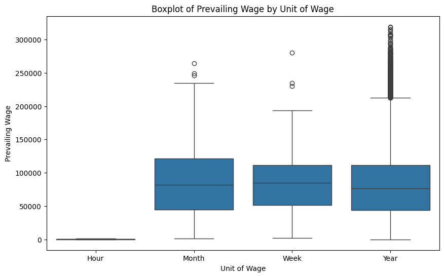

```python
# draw a boxplot to understand the wage distribution by unit of wage
plt.figure(figsize=(10, 6))
sns.boxplot(data=data, x='unit_of_wage', y='prevailing_wage')
plt.title('Boxplot of Prevailing Wage by Unit of Wage')
plt.xlabel('Unit of Wage')
plt.ylabel('Prevailing Wage')
plt.show()
```

**Observations**:

- Yearly Wages:
  - High spread with many outliers above ~$200,000.
  - Median wage appears lower than that of Month and Week units.
- Monthly & Weekly Wages:
  - Higher median wages than yearly (likely due to smaller sample sizes).
  - Fewer but still notable outliers, reaching ~$250,000.
- Hourly Wages:
  - Lowest overall, among wages and the distributon is compact
  - There are nearly no outliers, reflecting lower compensation levels

**Considerations**

- Given the challenges in the data for `prevailing_wage` across different units, normalising using basic techniques like 8hrs per day or 5 day working weeks for 52 weeks etc., the wages could lead to even more impact of outliers in the data

**Conclusion**

- The `prevailing_wage` will not be included in the analysis

## Feature engineering

### Label encode categorical columns (binary/categorical target columns)

- Following columns will be label encoded to 0 or 1
  1. `as_job_experience`
  2. `requires_job_training`
  3. `full_time_position`
  4. `case_status`

```python
# columns for label encoding
label_cols = ['has_job_experience', 'requires_job_training', 'full_time_position', 'case_status']

#loop through each column and using fit_transform normalise the labels
for col in label_cols:
    le = LabelEncoder()
    data[col] = le.fit_transform(data[col])
```

```python
#verify label encoding
data.head()
```

|  | continent | education_of_employee | has_job_experience | requires_job_training | no_of_employees | region_of_employment | prevailing_wage | unit_of_wage | full_time_position | case_status | company_age |
| --- | --- | --- | --- | --- | --- | --- | --- | --- | --- | --- | --- |
| 0 | Asia | High School | 0 | 0 | 14513 | West | 592.2029 | Hour | 1 | 1 | 18 |
| 1 | Asia | Master's | 1 | 0 | 2412 | Northeast | 83425.6500 | Year | 1 | 0 | 23 |
| 2 | Asia | Bachelor's | 0 | 1 | 44444 | West | 122996.8600 | Year | 1 | 1 | 17 |
| 3 | Asia | Bachelor's | 0 | 0 | 98 | West | 83434.0300 | Year | 1 | 1 | 128 |
| 4 | Africa | Master's | 1 | 0 | 1082 | South | 149907.3900 | Year | 1 | 0 | 20 |

### One-hot encode categorical columns (nominal)

- Following columns will be one hot encoded
  1. `continent`
  2. `education_of_employee`
  3. `region_of_employment`
  4. `unit_of_wage`

```python
#one hot encode columns
onehot_cols = ['continent', 'education_of_employee', 'region_of_employment', 'unit_of_wage']

#one hot encode and drop_first to avoid dummy variable trap
data = pd.get_dummies(data, columns=onehot_cols, drop_first=True)
```

```python
#verify one hot encoding
data.head()
```

|  | has_job_experience | requires_job_training | no_of_employees | prevailing_wage | full_time_position | case_status | company_age | continent_Asia | continent_Europe | continent_North America | ... | education_of_employee_Doctorate | education_of_employee_High School | education_of_employee_Master's | region_of_employment_Midwest | region_of_employment_Northeast | region_of_employment_South | region_of_employment_West | unit_of_wage_Month | unit_of_wage_Week | unit_of_wage_Year |
| --- | --- | --- | --- | --- | --- | --- | --- | --- | --- | --- | --- | --- | --- | --- | --- | --- | --- | --- | --- | --- | --- |
| 0 | 0 | 0 | 14513 | 592.2029 | 1 | 1 | 18 | True | False | False | ... | False | True | False | False | False | False | True | False | False | False |
| 1 | 1 | 0 | 2412 | 83425.6500 | 1 | 0 | 23 | True | False | False | ... | False | False | True | False | True | False | False | False | False | True |
| 2 | 0 | 1 | 44444 | 122996.8600 | 1 | 1 | 17 | True | False | False | ... | False | False | False | False | False | False | True | False | False | True |
| 3 | 0 | 0 | 98 | 83434.0300 | 1 | 1 | 128 | True | False | False | ... | False | False | False | False | False | False | True | False | False | True |
| 4 | 1 | 0 | 1082 | 149907.3900 | 1 | 0 | 20 | False | False | False | ... | False | False | True | False | False | True | False | False | False | True |

5 rows × 22 columns

```python
# display the final data info with one hot encoded columns before creation of models
data.info()
```

```
<class 'pandas.core.frame.DataFrame'>
RangeIndex: 25480 entries, 0 to 25479
Data columns (total 22 columns):
 #   Column                             Non-Null Count  Dtype
---  ------                             --------------  -----
 0   has_job_experience                 25480 non-null  int64
 1   requires_job_training              25480 non-null  int64
 2   no_of_employees                    25480 non-null  int64
 3   prevailing_wage                    25480 non-null  float64
 4   full_time_position                 25480 non-null  int64
 5   case_status                        25480 non-null  int64
 6   company_age                        25480 non-null  int64
 7   continent_Asia                     25480 non-null  bool
 8   continent_Europe                   25480 non-null  bool
 9   continent_North America            25480 non-null  bool
 10  continent_Oceania                  25480 non-null  bool
 11  continent_South America            25480 non-null  bool
 12  education_of_employee_Doctorate    25480 non-null  bool
 13  education_of_employee_High School  25480 non-null  bool
 14  education_of_employee_Master's     25480 non-null  bool
 15  region_of_employment_Midwest       25480 non-null  bool
 16  region_of_employment_Northeast     25480 non-null  bool
 17  region_of_employment_South         25480 non-null  bool
 18  region_of_employment_West          25480 non-null  bool
 19  unit_of_wage_Month                 25480 non-null  bool
 20  unit_of_wage_Week                  25480 non-null  bool
 21  unit_of_wage_Year                  25480 non-null  bool
dtypes: bool(15), float64(1), int64(6)
memory usage: 1.7 MB
```

## Prepare data for modeling

### Split data to train, validation, test sets

```python
# Drop 'prevailing_wage' from features and target variable 'case_status'
X = data.drop(['case_status', 'prevailing_wage'], axis=1)

# Set target variable
y = data['case_status']
```

```python
# Data split into 2 parts : temporary and test
X_temp, X_test, y_temp, y_test = train_test_split(
    X, y, test_size=0.2, random_state=1, stratify=y
)

# Temporary set split into train and validation
X_train, X_val, y_train, y_val = train_test_split(
    X_temp, y_temp, test_size=0.2, random_state=1, stratify=y_temp
)

# Create table of dataset shapes with y having 1 col
shapes = pd.DataFrame({
    'Dataset': ['X_train', 'y_train', 'X_val', 'y_val', 'X_test','y_test'],
    'Rows':   [X_train.shape[0], y_train.shape[0],
               X_val.shape[0], y_val.shape[0],
               X_test.shape[0], y_test.shape[0]],
    'Columns': [X_train.shape[1], 1,
                X_val.shape[1], 1,
                X_test.shape[1], 1]
})

print(shapes)
```

```
   Dataset   Rows  Columns
0  X_train  16307       20
1  y_train  16307        1
2    X_val   4077       20
3    y_val   4077        1
4   X_test   5096       20
5   y_test   5096        1
```

### Verify class balance

```python
# Create table class balance for whole data, train set, validation set, and test set
class_balance = pd.DataFrame({
    'Dataset' : ['y', 'y_train', 'y_val', 'y_test'],
    '0' : [y.value_counts(1)[0], y_train.value_counts(1)[0], y_val.value_counts(1)[0], y_test.value_counts(1)[0]],
    '1' : [y.value_counts(1)[1], y_train.value_counts(1)[1], y_val.value_counts(1)[1], y_test.value_counts(1)[1]]
})

print(class_balance)
```

```
   Dataset         0         1
0        y  0.667896  0.332104
1  y_train  0.667873  0.332127
2    y_val  0.667893  0.332107
3   y_test  0.667975  0.332025
```

### Impute the no_of_employees

```python
# Replace negative values with np.nan
X_train.loc[X_train["no_of_employees"] < 0, "no_of_employees"] = np.nan
X_val.loc[X_val["no_of_employees"] < 0, "no_of_employees"] = np.nan
X_test.loc[X_test["no_of_employees"] < 0, "no_of_employees"] = np.nan

# Impute the missing values with SimpleImputer
imp_median = SimpleImputer(missing_values=np.nan, strategy="median")

# fit the imputer on train data and transform the train data
X_train["no_of_employees"] = imp_median.fit_transform(X_train[["no_of_employees"]])

# transform the validation and test data using the imputer fit on train data
X_val["no_of_employees"] = imp_median.transform(X_val[["no_of_employees"]])
X_test["no_of_employees"] = imp_median.transform(X_test[["no_of_employees"]])
```

```python
# validate the count of no_of_employees less than zero to be none
print(X_train[X_train['no_of_employees'] < 0].shape[0])
print(X_val[X_val['no_of_employees'] < 0].shape[0])
print(X_test[X_test['no_of_employees'] < 0].shape[0])
```

```
0
0
0
```

# **3. Model Building - Original Data**

## Model Evaluation Criterion

### What does OFLC want?

- A reliable classification model to predict VISA approval outcomes.
- Insights into key decision factors that influence approvals/denials.

> Reference from problem statement : *Recommend a suitable profile for the applicants for whom the visa **should be certified or denied based** on the drivers that significantly influence the case status*.

### Where can the model go wrong?

- False Positives : Predicting a visa will be approved when it gets denied in reality could mislead employers and waste resources.
- False Negatives : Predicting a visa will be denied when it gets approved in reality may unfairly reject strong candidates.

### Which case is more important?

**False Positives** are more important to minimize, as predicting visa approval for candidates who ultimately get denied can:

- Mislead employers into investing time and resources in unqualified candidates.
- Undermine the credibility and efficiency of the visa processing system.
- This could also lead to challenges like non-compliance with regulations.

**False Negatives** are tolerable (but worth monitoring) as EasyVisa could reject someone who could have been approved

### Which metric to optimize?

Metrics to optimise in order

### How to reduce the losses?

- Use robust feature engineering and ensemble models (e.g., AdaBoost, GradientBoost, XGBoost, Bagging, Random Forest).
- Apply class imbalance handling (SMOTE, Random Under Sampling, class weights).
- Use hyper parameter tuning techniques

## Utility functions

```python
# defining a function to compute different metrics to check performance of a classification model built using sklearn
def model_performance_classification(model, predictors, target):
    """
    Function to compute different metrics to check classification model performance

    model: classifier
    predictors: independent variables
    target: dependent variable
    """

    # predicting using the independent variables
    pred = model.predict(predictors)

    acc = accuracy_score(target, pred)  # to compute Accuracy
    recall = recall_score(target, pred)  # to compute Recall
    precision = precision_score(target, pred)  # to compute Precision
    f1 = f1_score(target, pred)  # to compute F1-score

    # creating a dataframe of metrics
    df_perf = pd.DataFrame(
        {"Accuracy": acc, "Recall": recall, "Precision": precision, "F1": f1,},
        index=[0],
    )

    return df_perf
```

```python
# function to create a single DataFrame of training, validation performances
def model_performances(train, validation):

  #combine the dataframes across rows
  combined = pd.concat([train, validation],
                     axis=0,
                     keys=["Training", "Validation"])
  # drop the index
  combined.reset_index(level=1, drop=True)
  return combined
```

```python
# function to plot the confusion matrix of training and validation, side by side
def plot_confusion_matrices_v2(model, training_predictors, training_target,
                               validation_predictors, validation_target,
                               validation_label = 'Validation Confusion Matrix'):
    """
    Plots side-by-side confusion matrices for training and validation datasets.

    model: trained classifier
    training_predictors, training_target: training features and labels
    validation_predictors, validation_target: validation features and labels
    """

    def compute_cm_labels(cm):
        labels = np.asarray(
            [
                f"{item}\n{item/cm.sum():.2%}"
                for item in cm.flatten()
            ]
        ).reshape(2, 2)
        return labels

    # Predict on training and validation data
    y_train_pred = model.predict(training_predictors)
    y_val_pred = model.predict(validation_predictors)

    # Compute confusion matrices
    cm_train = confusion_matrix(training_target, y_train_pred)
    cm_val = confusion_matrix(validation_target, y_val_pred)

    # Compute labels
    labels_train = compute_cm_labels(cm_train)
    labels_val = compute_cm_labels(cm_val)

    # Plot side-by-side
    fig, axes = plt.subplots(1, 2, figsize=(10,4))

    # create training confusion matrix
    sns.heatmap(cm_train, annot=labels_train, fmt="", ax=axes[0])
    axes[0].set_title("Training Confusion Matrix")
    axes[0].set_xlabel("Predicted label")
    axes[0].set_ylabel("True label")

    # create testing / validation confusion matrix
    sns.heatmap(cm_val, annot=labels_val, fmt="", ax=axes[1])
    axes[1].set_title(validation_label)
    axes[1].set_xlabel("Predicted label")
    axes[1].set_ylabel("True label")

    plt.tight_layout()
    plt.show()
```

```python
# function to create the dataframe comparing original and sampled data
def create_sample_comparison(predictor, validator, predictor_sampled, validator_sampled):
  sampled_data_frame = {
    'Label 1 Count': [
        sum(validator == 1),
        sum(validator_sampled == 1)
    ],
    'Label 0 Count': [
        sum(validator == 0),
        sum(validator_sampled == 0)
    ],
    'X Shape': [
        predictor.shape,
        predictor_sampled.shape
    ],
    'y Shape': [
        validator.shape,
        validator_sampled.shape
    ]
  }
  # Create the DataFrame with appropriate index labels
  df_summary = pd.DataFrame(sampled_data_frame, index=['Before Sampling', 'After Sampling'])
  return df_summary
```

## M1 : Decision Tree (sklearn default)

- A basic DecisionTree model will be built.
- The model will be fit on training data set and predicted on validation data set
- All the 4 metrics F1 Score, Precision, Recall and Accuracy will be studied with priority to F1 score

**Note :** No hyper parameters will be provided.

```python
# creating an instance of the decision tree model
# random_state sets a seed value and enables reproducibility
dtree_default = DecisionTreeClassifier(random_state=1)

# fitting the model to the training data
dtree_default.fit(X_train, y_train)
```

```
DecisionTreeClassifier(random_state=1)
```

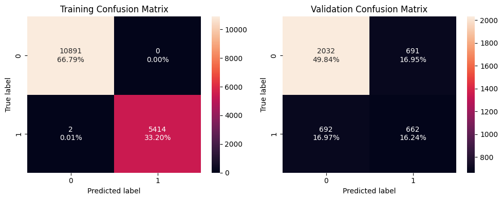

```python
# plot confusion matrices for training, validation data
plot_confusion_matrices_v2(dtree_default, X_train, y_train, X_val, y_val)
```

```python
# compute performance metrics on training data set
dtree_default_train_perf = model_performance_classification(
    dtree_default, X_train, y_train
)

# compute performance metrics on validation data
dtree_default_val_perf = model_performance_classification(
    dtree_default, X_val, y_val
)

# print and compare model performances
dtree_performance = model_performances(dtree_default_train_perf, dtree_default_val_perf)
dtree_performance
```

|  |  | Accuracy | Recall | Precision | F1 |
| --- | --- | --- | --- | --- | --- |
| Training | 0 | 0.999877 | 0.999631 | 1.000000 | 0.999815 |
| Validation | 0 | 0.660780 | 0.488922 | 0.489283 | 0.489102 |

### Model Summary

- Training F1 score is excellent at 0.999, indicating near-perfect performance.
- Validation F1 score drops sharply to 0.489, showing severe overfitting.
- Precision on training is perfect (1.0), but falls to 0.489 on validation.
- Large gap between training and validation metrics suggests poor generalization.
- Model is likely memorizing training data rather than learning general patterns.

## M2 : Bagging Classifier

- A basic Bagging Classifier model will be built. Base estimator for bagging classifier is a decision tree by default
- The model will be fit on training data set and predicted on validation data set
- All the 4 metrics F1 Score, Precision, Recall and Accuracy will be studied with priority to F1 score

**Note :** No hyper parameters will be provided.

```python
#create bagging classifier and fit to training data
bagging_classifier=BaggingClassifier(random_state=1)
bagging_classifier.fit(X_train,y_train)
```

```
BaggingClassifier(random_state=1)
```

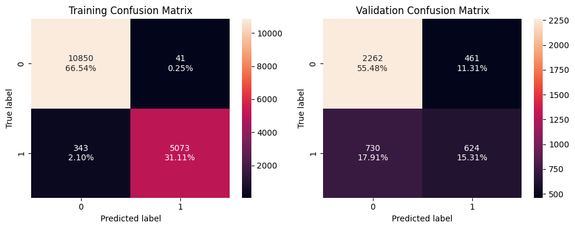

```python
# plot confusion matrices for training, validation data
plot_confusion_matrices_v2(bagging_classifier, X_train, y_train, X_val, y_val)
```

```python
# compute performance metrics on training data set
bagging_classifier_train_perf = model_performance_classification(
    bagging_classifier, X_train, y_train
)

# compute performance metrics on validation data
bagging_classifier_val_perf = model_performance_classification(
    bagging_classifier, X_val, y_val
)

# print and compare model performances
bagging_classifier_performance = model_performances(bagging_classifier_train_perf, bagging_classifier_val_perf)
bagging_classifier_performance
```

|  |  | Accuracy | Recall | Precision | F1 |
| --- | --- | --- | --- | --- | --- |
| Training | 0 | 0.976452 | 0.936669 | 0.991983 | 0.963533 |
| Validation | 0 | 0.707873 | 0.460857 | 0.575115 | 0.511685 |

### Model summary

- Training F1: 0.963 — still very high, indicating near-perfect learning on training data.
- Validation F1: 0.511 — much lower, showing the model struggles on unseen data.
- F1 gap: A large drop, confirming overfitting is present.
- Precision gap: 0.991 (train) vs. 0.575 (val) is also significant, reinforcing overfitting.
- Compared to Decision Tree: Smaller performance gap, but still fails to generalize well.

## M3 : Random Forest Classifier

- A basic RandomForestClassifier model will be built.
- The model will be fit on training data set and predicted on validation data set
- All the 4 metrics F1 Score, Precision, Recall and Accuracy will be studied with priority to F1 score

**Note :** No hyper parameters will be provided.

```python
#Train the random forest classifier
rf_classifier=RandomForestClassifier(random_state=1)
rf_classifier.fit(X_train,y_train)
```

```
RandomForestClassifier(random_state=1)
```

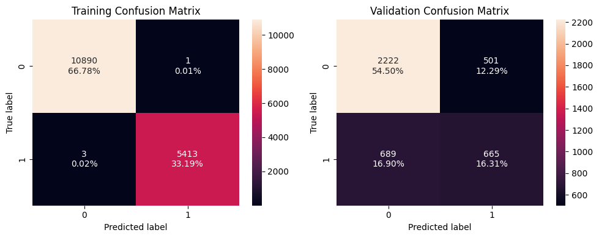

```python
# plot confusion matrices for training, validation data
plot_confusion_matrices_v2(rf_classifier, X_train, y_train, X_val, y_val)
```

```python
# compute performance metrics on training data set
rf_classifier_train_perf = model_performance_classification(
    rf_classifier, X_train, y_train
)

# compute performance metrics on validation data
rf_classifier_val_perf = model_performance_classification(
    rf_classifier, X_val, y_val
)

# print and compare model performances
rf_classifier_performance = model_performances(rf_classifier_train_perf, rf_classifier_val_perf)
rf_classifier_performance
```

|  |  | Accuracy | Recall | Precision | F1 |
| --- | --- | --- | --- | --- | --- |
| Training | 0 | 0.999755 | 0.999446 | 0.999815 | 0.999631 |
| Validation | 0 | 0.708119 | 0.491137 | 0.570326 | 0.527778 |

### Model summary

- Training F1 score is 0.999, indicating near-perfect fit on training data.
- Validation F1 score is 0.527, showing moderate generalization with a large performance gap.
- Validation precision is 0.570, suggesting reasonable reliability in positive predictions.
- Significant difference between training and validation F1 confirms overfitting.
- Compared to BaggingClassifier, RandomForest performs slightly better on validation, but still suffers from overfitting.

## M4 : AdaBoost Classifier

- A basic AdBoostClassifier model will be built.
- The model will be fit on training data set and predicted on validation data set
- All the 4 metrics F1 Score, Precision, Recall and Accuracy will be studied with priority to F1 score

**Note :** No hyper parameters will be provided.

```python
#Train the adaboost classifier
ada_boost_classifier = AdaBoostClassifier(random_state=1)
ada_boost_classifier.fit(X_train,y_train)
```

```
AdaBoostClassifier(random_state=1)
```

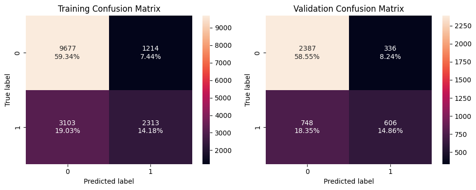

```python
# plot confusion matrices for training, validation data
plot_confusion_matrices_v2(ada_boost_classifier, X_train, y_train, X_val, y_val)
```

```python
# compute performance metrics on training data set
ada_boost_classifier_train_perf = model_performance_classification(
    ada_boost_classifier, X_train, y_train
)

# compute performance metrics on validation data
ada_boost_classifier_val_perf = model_performance_classification(
    ada_boost_classifier, X_val, y_val
)

# print and compare model performances
ada_boost_classifier_performance = model_performances(ada_boost_classifier_train_perf, ada_boost_classifier_val_perf)
ada_boost_classifier_performance
```

|  |  | Accuracy | Recall | Precision | F1 |
| --- | --- | --- | --- | --- | --- |
| Training | 0 | 0.735267 | 0.427068 | 0.655798 | 0.517276 |
| Validation | 0 | 0.734118 | 0.447563 | 0.643312 | 0.527875 |

### Model summary

- Training F1 score is 0.517, indicating moderate learning on the training data.
- Validation F1 score is 0.527, very close to training, suggesting minimal overfitting. But also limited overall performance
- Validation precision is 0.643, the highest among all models so far, indicating strong reliability in positive predictions.
- Low recall (0.447) on validation indicates many false negatives
- Consistency between training and validation metrics reflects better generalization. May require better feature engineering or hyperparameter tuning.

## M5 : Gradient Boost Classifier

- A basic GradientBoostClassifier model will be built.
- The model will be fit on training data set and predicted on validation data set
- All the 4 metrics F1 Score, Precision, Recall and Accuracy will be studied with priority to F1 score

**Note :** No hyper parameters will be provided.

```python
#Train the gradient classifier
gradient_boost_classifier = GradientBoostingClassifier(random_state=1)
gradient_boost_classifier.fit(X_train,y_train)
```

```
GradientBoostingClassifier(random_state=1)
```

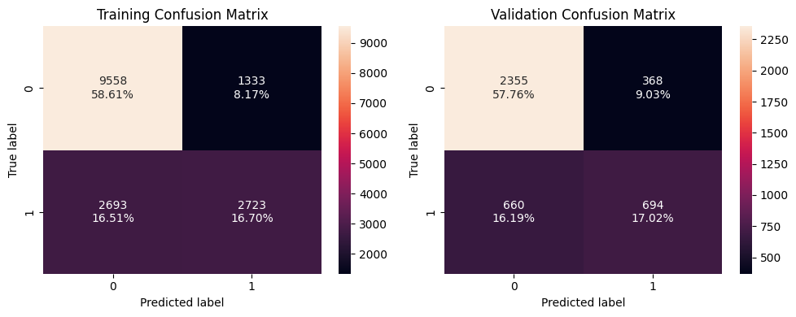

```python
# plot confusion matrices for training, validation data
plot_confusion_matrices_v2(gradient_boost_classifier, X_train, y_train, X_val, y_val)
```

```python
# compute performance metrics on training data set
gradient_boost_classifier_train_perf = model_performance_classification(
    gradient_boost_classifier, X_train, y_train
)

# compute performance metrics on validation data
gradient_boost_classifier_val_perf = model_performance_classification(
    gradient_boost_classifier, X_val, y_val
)

# print and compare model performances
gradient_boost_classifier_performance = model_performances(gradient_boost_classifier_train_perf, gradient_boost_classifier_val_perf)
gradient_boost_classifier_performance
```

|  |  | Accuracy | Recall | Precision | F1 |
| --- | --- | --- | --- | --- | --- |
| Training | 0 | 0.753112 | 0.502770 | 0.671351 | 0.574958 |
| Validation | 0 | 0.747854 | 0.512555 | 0.653484 | 0.574503 |

### Model summary

- F1 scores for training (**0.574**) and validation (**0.574**) are nearly identical, indicating good generalization.
- Precision is **0.653**, making the model reliable in positive predictions.
- Recall is moderate (**0.512**), suggesting the model misses a significant portion of true positives.
- Overall performance is balanced and better than previous models, with lesser overfitting. Further improvement (better feature engineering or hyperparameter tuning) is needed in recall and overall accuracy (**0.747**) to enhance effectiveness.